# Обработка текста

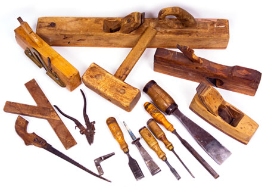

Кирилл Корняков (Itseez, ННГУ)  
Сентябрь 2013

# Содержание

1. Текстовые редакторы
2. Возможности современных редакторов (на примере Sublime)
3. Регулярные выражения
4. Инструменты командной строки
5. Краткое упоминание про скриптовые языки

# Два совета

1. Освойте слепой метод печати
   - Вы начинаете работать "со скоростью мысли"
   - Мозгу не нужно переключаться, вы фокусируетесь на задаче
   - Это полезно для глаз
   - Тренажеры: [русский](http://vse10.ru), [английский](http://www.ratatype.com)
2. Избегайте использования мыши
   - Экономия до 30% рабочего времени
   - Освойте клавиатурные комбинации ("горячие клавиши")

# Текстовые редакторы

"Программист-прагматик":

> Используйте один текстовый редактор, но по максимуму.

**Важные свойства редакторов:**

- Кросс-платформенность
- Настраиваемость
  - Шрифты, оформление, клавиатурные комбинации
- Расширяемость
  - Новые языки программирования и форматы файлов
- Программируемость
  - Программируемость сложных операций (макросы, сценарии)
- Скорость работы

# Vim

[figure not shown]

- Vim - свободный текстовый редактор, созданный на базе vi.
- Один из культовых редакторов.
- Один из мощнейших редакторов, с полной свободой настройки и автоматизации.
- Имеет огромное количество расширений (более 3000).
- Используется практически в любых проектах.
- Официальный сайт проекта: http://www.vim.org.

# Vim UI

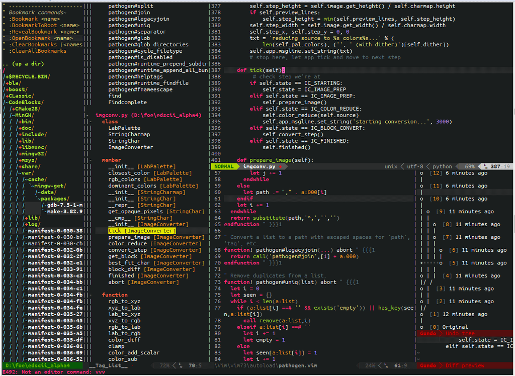

# Vim Cheatsheet

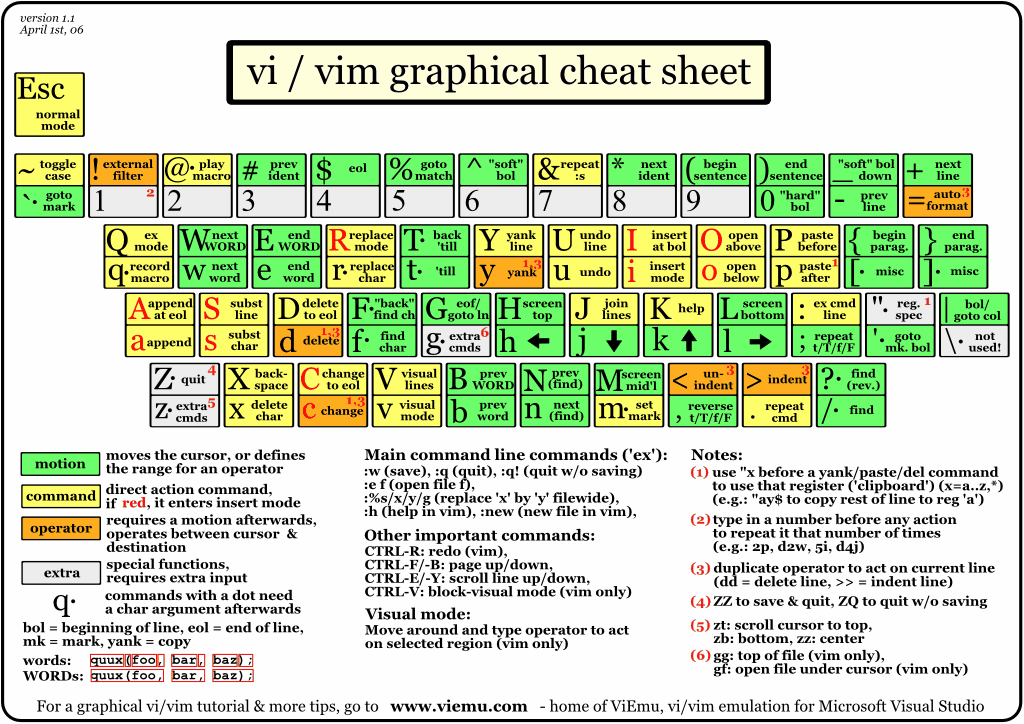

# Vim examples

- `5D`, `Y5p` - удалить/повторить строку 5 раз
- `/^joe` - найти все строки, начинающиеся с joe
- `:g!/REGEXP/d` - удалить все строки, не содержащие REGEXP
- `:%norm jdd` - удалить каждую вторую строку
- `ci(`, `ci[` - удалить содержимое внутри скобок
- `guu`, `gUU` - перевести всю строку в нижний/верхний регистр

Настройки Vim

- `:history` - показать историю команд
- `:set number` - показать номера строк

# Emacs

[figure not shown]

- Emacs - семейство расширяемых многофункциональных текстовых редакторов.
- Второй культовый редактор.
- Возможно еще более мощный редактор, чем Vim (Emacs as OS).
- Имеет более 2000 встроенных команд, позволяет комбинировать их в макросы.
- Официальный сайт проекта http://www.gnu.org/software/emacs/.

# Emacs UI

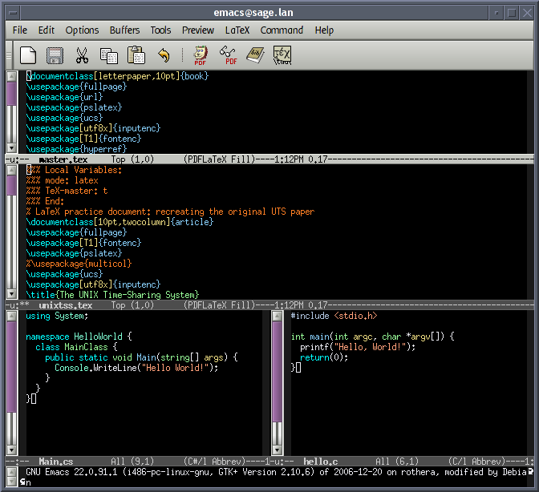

# Идеология Emacs

- «Всё в одном»
  - Функциональность: базовая, основной режим, дополнительные режимы
- Расширяемость
  - Программируется на Elisp, имеются пакеты расширений, клавиатурные комбинации
- Настраиваемость под пользователя
  - Elisp-переменные, определение функций, создание hook'ов
- Документированность
  - Подробная документация, вплоть до функций и переменных

# Sublime Text

[figure not shown]

- Sublime Text - кроссплатформенный редактор текста и кода.
- Имеет Python API, существует большое количество раширений.
- Не является свободным, однако почти все расширения открыты.
- Становится все более популярным.
- Официальный сайт проекта http://www.sublimetext.com/.

# Sublime Text UI

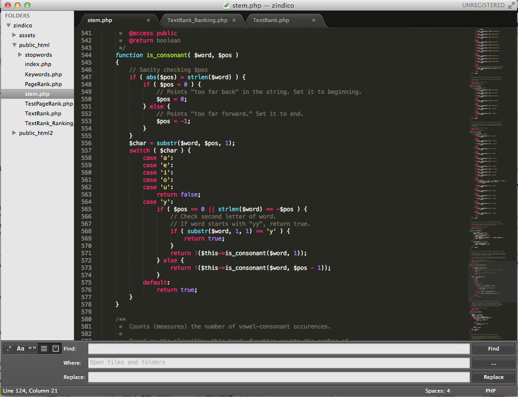

# Sublime Text Горячие клавиши

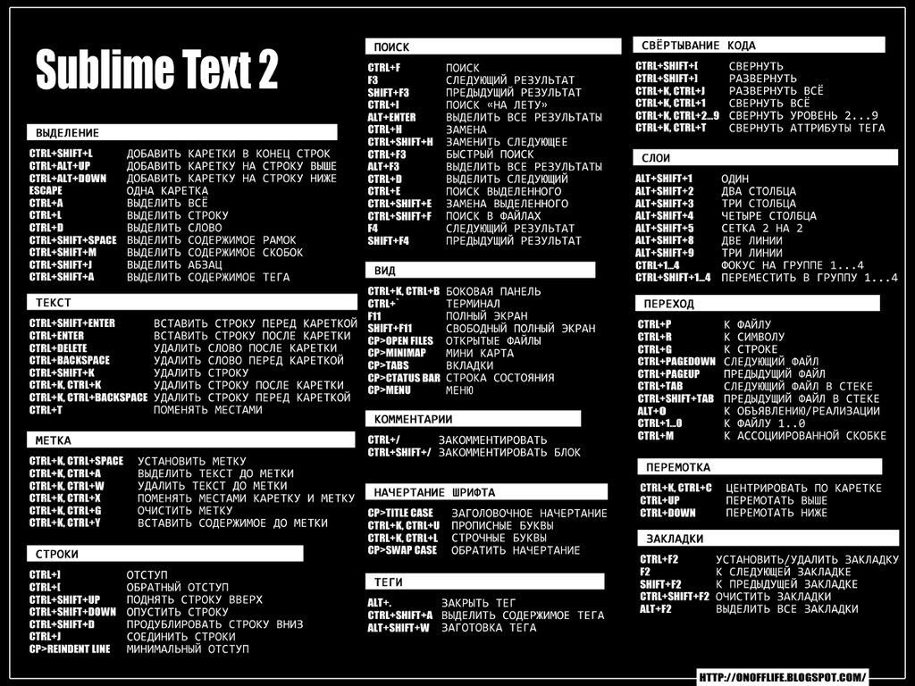

# Содержание

1. Текстовые редакторы
2. Возможности современных редакторов (на примере Sublime)
3. Регулярные выражения
4. Инструменты командной строки
5. Краткое упоминание про скриптовые языки

# Типичные операции

- Навигация
- Выделение
- Поиск (и замена)
- Редактирование

# Навигация

1. По файлам
   - Перебор закладок
   - Боковая панель
   - **Go to anything**
2. Внутри файлов
   - Хождение по словам, строкам, экрану
   - Переход на строку
   - Переход между скобками
   - **Go to symbol**

# Выделение

1. Слов, Строк
2. Абзацев
3. Выражений внутри скобок
4. Всех вхождений слова => Поиск

# Поиск

1. Простой поиск
   - **Multiple cursor**
   - **Регулярные выражения**
2. Инкрементальный
3. Быстрый

# Редактирование

1. Комментирование
2. Перестановка двух символов
3. Удаление: слов, строк, окончаний строк
4. Манипуляции со строками
   - Дублирование, переупорядочение, сортировка
   - Слияние и автоматический перенос
5. Редактирование нескольких строк и прямоугольных регионов

# Продвинутые возможности

1. Package Control
2. Snippets
3. Vintage Mode
4. Custom Builds
5. Projects

# Содержание

1. Текстовые редакторы
2. Возможности современных редакторов (на примере Sublime)
3. Регулярные выражения
4. Инструменты командной строки
5. Краткое упоминание про скриптовые языки

# Регулярные выражения

> **Регулярные выражения** (англ. regular expressions) — формальный язык поиска и осуществления манипуляций с подстроками в тексте, основанный на использовании метасимволов (англ. wildcard characters).

> По сути это строка-образец (англ. pattern, по-русски её часто называют «шаблоном», «маской»), состоящая из символов и метасимволов и задающая правило поиска.

Wikipedia

Метасимволы: `[ ] \ / ^ $ . | ? * + ( ) { }`

# Примеры регулярных выражений

(Даются упрощенные выражения)

- Email: `[a-z]+@[a-z]+\.com`
- Visa: `4[0-9]{3}(\ [0-9]{4}){3}`
- IP: `\b\d{1,3}\.\d{1,3}\.\d{1,3}\.\d{1,3}\b`
- Float: `[-+]?[0-9]+\.[0-9]+`
- Years old:
  - `[0-9]{2}(?=\ years)`
  - `(?<=[0-9]{4}\ \()[0-9]{2}`

# Синтаксис

- Обычные строки обозначают сами себя
- `.` - может быть использована вместо любого символа
- `\` - экранирует метасимволы (`/` иногда используется как разделитель)
- `( )` - группировка, указывает приоритет операций
- `[ ]` - обозначает символьный класс (`[abc], [0123456789], [а-я], [0-9]`)
- `^ $` - указывают на начало и конец строки
- `? * + { }` - указывают число повторений

# Примеры регулярных выражений

Что ищут эти выражения, и какие они имеют недостатки?

- `[a-z]+@[a-z]+\.com`
- `4[0-9]{3}(\ [0-9]{4}){3}`
- `\b\d{1,3}\.\d{1,3}\.\d{1,3}\.\d{1,3}\b`
- `[-+]?[0-9]+\.[0-9]+`
- Lookaround
  - lookahead: `[0-9]{2}(?=\ years)`
  - lookbehind: `(?<=[0-9]{4}\ \()[0-9]{2}`

# Содержание

1. Текстовые редакторы
2. Возможности современных редакторов (на примере Sublime)
3. Регулярные выражения
4. Инструменты командной строки
5. Краткое упоминание про скриптовые языки

# Инструменты командной строки

1. Просмотр
   - `cat/tac`, `head/tail`, `less`
2. Поиск
   - `grep`
3. Обработка
   - `sed`, `awk`

# Grep examples

- `grep -nIHR "^#" --include=*.md ./`
  - Вывод всех заголовков в Markdown файлах ("`| wc -l`" добавит их подсчет)
- `grep -nIHR "class.*Matcher" --include=*.hpp -B1 ./`
  - Печать деклараций всех классов, содержащих слово Matcher (+одна строка до)

# Sed examples

Stream editor

- `sed 's/foo/bar/g'` - заменяет foo на bar
- `sed '/baz/s/foo/bar/g'` - то же самое, но если строка содержит baz
- `sed 's/[ \t]*$//'` - удалить "висячие" пробельные символы
- `sed '/regex/G'` - вставить пустую строку под каждой, содержащей "regex"
- `sed 'n;n;n;n;G;'` - вставить пустую строку через каждые 5
- `sed -n '$='` - посчитать количество строк
- `sed '1,10d'` - удалить первые 10 строк файла

# Awk examples

awk - pattern-directed scanning and processing language

Authors: Aho, Weinberger, Kernighan

Примеры:

- `awk '{print NR "\t" $0}'` - распечатать файл с номерами строк
- `awk 'END{print NR}'` - вывести число строк в файле
- `awk '{print $2, $1}'` - распечатать второе и первое поле в обратном порядке
- `awk '{s=0; for (i=1; i<=NF; i++) s=s+$i; print s}'` - вывести сумму полей для каждой строки
- `awk '{sub(/[ \t]+$/, "")};1'` - удалить "висячие" пробельные символы
- `awk '{l=length();s=int((79-l)/2); printf "%"(s+l)"s\n",$0}' filename` - центрировать и распечатать файл

# Составные примеры

- Суммировать проценты в определенных строках лога

```
$ grep -nIHR "HPWL impr" ./vlsi.log | sed -n '1,5p' |
 awk '{ print $NF }' | awk '{for (i=1; i<=NF; i++) s=s+$i}; END{print s}'
```

```
$ cat coords1.dat coords2.dat | sort | sed 's/.0//g' > output.dat
```

# Содержание

1. Текстовые редакторы
2. Возможности современных редакторов (на примере Sublime)
3. Регулярные выражения
4. Инструменты командной строки
5. Краткое упоминание про скриптовые языки

# Скриптовые языки

- Perl
  - Practical Extraction and Report Language
  - Создан Ларри Уоллом, лингвистом по образованию
  - Замена для `awk` и `sed`
  - Богатые возможности по работе с текстом,  
    встроенная в синтаксис поддержка регулярных выражений
- Python
  - Есть мнение, что он все-таки победил как язык общего назначения

# Резюме

1. Освойте слепой метод набора текста
2. Выберите себе текстовый редактор, и изучите его досконально
   - Попробуйте программировать в текстовом редакторе
3. Распечатайте шпаргалку с горячими клавишами
   - Постарайтесь не использовать мышь для навигации, выделения
4. Освойте регулярные выражения
   - Используйте их для поиска и замены, пакетной обработки файлов
5. Установите и изучите инструменты командной строки
   - cat, less, head/tail
   - grep, sed, awk

# Контрольные вопросы

1. Как будет выглядет команда в Vim для:
   - Создания 10 копий текущей строки
   - Перевода всей строки в верхний регистр (капитализация)
2. Предложите регулярное выражение для поиска:
   - Имен всех классов в вашем С++ проекте
   - Поиска всех дат в формате 2013-09-18 или 14-01-01
3. Предложите командную строку для:
   - Поиска всех вызовов виртуального метода в директории с исходниками
   - Печати всех заголовков первого и второго уровня в файле Markdown (#-нотация)

# Спасибо!

Вопросы?